# gis_r_sofia

2022-11-22

Hoy vamos a aprender a extraer datos climáticos de archivos .nc

What is a .nc file?

*NetCDF is a widely used format for exchanging or distributing climate data, and has also been adopted in other fields, particularly in bioinformatics, and in other disciplines where large multidimensional arrays of data are generated. NetCDF files are self-describing, in the sense that they contain metadata that describes what is contained in a file, such as the latitude and longitude layout of the grid, the names and units of variables in the data set, and “attributes” that describe things like missing value codes, or offsets and scale factors that may have been used to compress the data. NetCDF files are also machine-independent because can be transferred among servers and computers that are running different operating systems, without having to convert the files in some way.*

# Leer el archivo

Vamos primero a tratar de cargar nuestro archivo.

```r
ncpath <- "E:/Climate_data/spain02/" #la dirección donde se encuentra
ncname <- "Spain02_v5.0_DD_010reg_aa3d_tasmax"  #nombre del archivo
ncfname <- paste(ncpath, ncname, ".nc", sep="") #lo unimos
```

En el otro taller vimos como trabajar con ello con el paquete raster.

```r
library(raster)
ras <- brick(ncfname)
str(ras)
```

```
## Formal class 'RasterBrick' [package "raster"] with 12 slots
##   ..@ file    :Formal class '.RasterFile' [package "raster"] with 13 slots
##   .. .. ..@ name        : chr "E:\\Climate_data\\spain02\\Spain02_v5.0_DD_010reg_aa3d_tasmax.nc"
##   .. .. ..@ datanotation: chr "FLT4S"
##   .. .. ..@ byteorder   : chr "little"
##   .. .. ..@ nodatavalue : num -9999
##   .. .. ..@ NAchanged   : logi FALSE
##   .. .. ..@ nbands      : int 24106
##   .. .. ..@ bandorder   : chr "BIL"
##   .. .. ..@ offset      : int 0
##   .. .. ..@ toptobottom : logi TRUE
##   .. .. ..@ blockrows   : int 0
##   .. .. ..@ blockcols   : int 0
##   .. .. ..@ driver      : chr "netcdf"
##   .. .. ..@ open        : logi FALSE
##   ..@ data    :Formal class '.MultipleRasterData' [package "raster"] with 14 slots
##   .. .. ..@ values    : logi[0 , 0 ]
##   .. .. ..@ offset    : num 0
##   .. .. ..@ gain      : num 1
##   .. .. ..@ inmemory  : logi FALSE
##   .. .. ..@ fromdisk  : logi TRUE
##   .. .. ..@ nlayers   : int 24106
##   .. .. ..@ dropped   : NULL
##   .. .. ..@ isfactor  : logi FALSE
##   .. .. ..@ attributes: list()
##   .. .. ..@ haveminmax: logi FALSE
##   .. .. ..@ min       : num [1:24106] Inf Inf Inf Inf Inf ...
##   .. .. ..@ max       : num [1:24106] -Inf -Inf -Inf -Inf -Inf ...
##   .. .. ..@ unit      : chr "degree_Celsius"
##   .. .. ..@ names     : chr [1:24106] "X1950.01.01" "X1950.01.02" "X1950.01.03" "X1950.01.04" ...
##   .. .. ..$ zvar : chr "tasmax"
##   .. .. ..$ dim3 : int 3
##   .. .. ..$ level: num 0
##   ..@ legend  :Formal class '.RasterLegend' [package "raster"] with 5 slots
##   .. .. ..@ type      : chr(0)
##   .. .. ..@ values    : logi(0)
##   .. .. ..@ color     : logi(0)
##   .. .. ..@ names     : logi(0)
##   .. .. ..@ colortable: logi(0)
##   ..@ title   : chr "2-meter maximum daily air temperature"
##   ..@ extent  :Formal class 'Extent' [package "raster"] with 4 slots
##   .. .. ..@ xmin: num -9.35
##   .. .. ..@ xmax: num 4.45
##   .. .. ..@ ymin: num 36
##   .. .. ..@ ymax: num 43.8
##   ..@ rotated : logi FALSE
##   ..@ rotation:Formal class '.Rotation' [package "raster"] with 2 slots
##   .. .. ..@ geotrans: num(0)
##   .. .. ..@ transfun:function ()
##   ..@ ncols   : int 138
##   ..@ nrows   : int 79
##   ..@ crs     :Formal class 'CRS' [package "sp"] with 1 slot
##   .. .. ..@ projargs: chr "+proj=longlat +datum=WGS84 +no_defs"
##   .. .. ..$ comment: chr "GEOGCRS[\"unknown\",\n    DATUM[\"World Geodetic System 1984\",\n        ELLIPSOID[\"WGS 84\",6378137,298.25722"| __truncated__
##   ..@ history : list()
##   ..@ z       :List of 1
##   .. ..$ Date: Date[1:24106], format: "1950-01-01" "1950-01-02" ...
```

```r
tail(ras@data@names)
```

```
## [1] "X2015.12.26" "X2015.12.27" "X2015.12.28" "X2015.12.29" "X2015.12.30"
## [6] "X2015.12.31"
```

El problema es que usando este paquete, nosotros necesitamos saber previamente la estructura del archivo para poder entenderlo . Si usamos en cambio el paquete ncdf4, los propios metadatos del archivo nos van a indicar su estructura.

Usamos la función *nc_open* para abrirlo.

```r
library(ncdf4)
ncin <- nc_open(ncfname)
print(ncin)
```

```
## File E:/Climate_data/spain02/Spain02_v5.0_DD_010reg_aa3d_tasmax.nc (NC_FORMAT_NETCDF4_CLASSIC):
##
##      1 variables (excluding dimension variables):
##         float tasmax[lon,lat,time]   (Contiguous storage)
##             standard_name: air_temperature
##             long_name: 2-meter maximum daily air temperature
##             units: degree_Celsius
##             missing_value: -9999
##             coordinates: lat lon time
##
##      3 dimensions:
##         time  Size:24106
##             long_name: Time variable
##             units: days since 1950-01-01 00:00:00
##             _CoordinateAxisType: Time
##         lat  Size:79
##             standard_name: latitude
##             long_name: latitude
##             units: degrees north
##             _CoordinateAxisType: Lat
##         lon  Size:138
##             standard_name: longitude
##             long_name: longitude
##             units: degrees east
##             _CoordinateAxisType: Lon
##
##     9 global attributes:
##         institution: Santander Meteorology Group (UC-CSIC, www.meteo.unican.es)
##         references1: Herrera, S., J. M. Gutierrez, R. Ancell, M. R. Pons, M. D. Frias, and J. Fernandez, 2012: Development and analysis of a 50-year high-resolution daily gridded precipitation dataset over Spain (Spain02). Int. J. Climatol., 32, 74--85. DOI: 10.1002/joc.2256
##         references2: Herrera, S., Fernandez, J. and Gutierrez, J.M. (2016) Update of the Spain02 Gridded Observational Dataset for Euro-CORDEX evaluation: Assessing the Effect of the Interpolation Methodology. Int. J. Climatol., 36, 900--908, DOI: 10.1002/joc.4391
##         webpage: http://www.meteo.unican.es/en/datasets/spain02
##         version: 5.0
##         title: SPAIN02: daily gridded precipitation and temperature datasets for Spain
##         Conventions: CF-1.6
##         conventionsURL: http://www.cgd.ucar.edu/cms/eaton/cf-metadata/index.html
##         creation_date: 20-Dec-2017 09:56:22
```

Nos da toda la info que necesitamos: las dimensiones (tiempo, longitud, latitud), las unidades de la misma, el titulo, referencias…

Otras maneras de conseguir información de los metadatos:

```r
title <- ncatt_get(ncin,0,"title")
title
```

```
## $hasatt
## [1] TRUE
##
## $value
## [1] "SPAIN02: daily gridded precipitation and temperature datasets for Spain"
```

```r
institution <- ncatt_get(ncin,0,"institution")
institution
```

```
## $hasatt
## [1] TRUE
##
## $value
## [1] "Santander Meteorology Group (UC-CSIC, www.meteo.unican.es)"
```

Vamos ahora con las variables, que es lo que realmente nos interesa.

Sabemos que se llama *tasmax* porque lo ponía en el print.

```r
dname <- "tasmax"
```

También vemos que en este caso las unidades de tiempo son “días desde 1950/01/01”:

```r
tunits <- ncatt_get(ncin,"time","units")
tunits
```

```
## $hasatt
## [1] TRUE
##
## $value
## [1] "days since 1950-01-01 00:00:00"
```

```r
time <- ncvar_get(ncin,"time")
nt <- dim(time)
nt
```

```
## [1] 24106
```

Y también que tenemos 24106 días de datos.

Pongamos ahora que queremos obtener la longitud y latitud:

```r
lon <- ncvar_get(ncin,"lon")
dim(lon)
```

```
## [1] 138
```

```r
lat <- ncvar_get(ncin,"lat")
dim(lat)
```

```
## [1] 79
```

En fin, se pueden conseguir mil cosas más, en este [enlace](https://pjbartlein.github.io/REarthSysSci/netCDF.html#reading-restructuring-and-writing-netcdf-files-in-r) podéis obtener más información.

# Obtener los datos de las variables

Vamos a lo que interesa: conseguir los datos.

```r
tmp_array <- ncvar_get(ncin,dname)
dim(tmp_array)
```

```
## [1]   138    79 24106
```

A continuación tenemos un array de las siguientes dimensiones : un grid 138 (long)* 79 (lat) con 24106 capitas (dias de 1950 a 2015).

Recordemos que para indexar las dimensiones de un array hay que usar [ , , ]

Si quisiera el dato de la segunda fila, primera columna de la cuarta capa: [2,1,4]

Si quisiera los datos de la capa 15 [ , ,15]

### Plot rápido del 1 de enero de 1950 usando rbase:

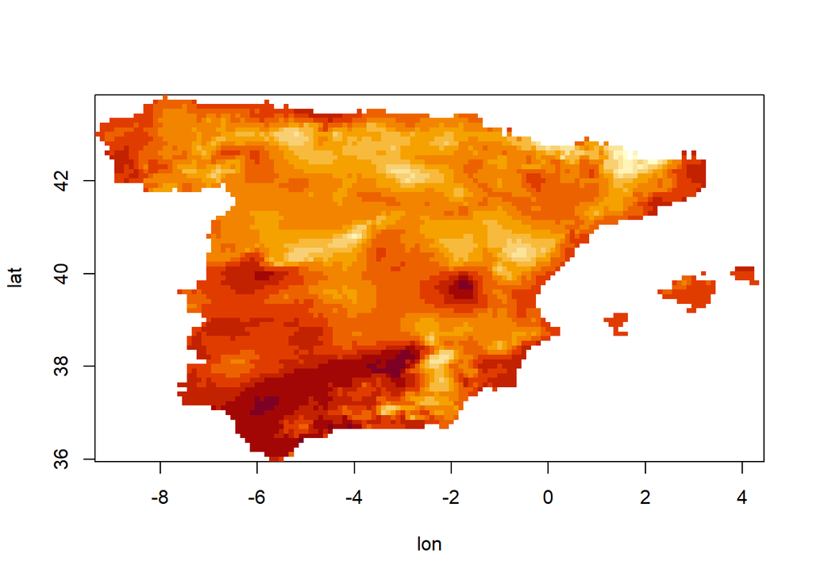

```r
image(lon,lat,tmp_array[,,1])
```

### Plot rápido del 1 de enero de 1950 usando el paquete lattice:

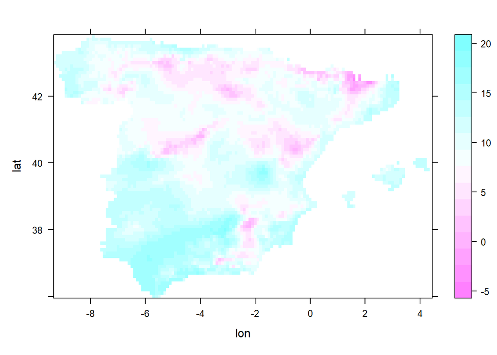

```r
library(lattice)
grid <- expand.grid(lon=lon, lat=lat)
levelplot((tmp_array[,,1]) ~ lon * lat, grid)
```

### Hacer subset de datos de un período concreto

Tenemos el problema de que las capas no tienen nombres, por tanto a la haora de hacer un subset, la manera en la que a mí me resulta más intuitiva trabajar con fechas es esta:

Pongamos que queremos hacer un subset de por ejemplo, los datos climáticos desde el nacimiento al fallecimiento de Whitney Houston.

[video not shown]

Primero voy a crear un vector con la lista de días que tengo.

```r
list_days <- seq(as.Date("1950-01-01"), as.Date("2015-12-31"),
                 by="days")
```

A continuación, vamos a encontrar la posición numérica en dicho vector de nuestras fechas, que son el nacimiento y fallecimiento de Whitney Houston.

```r
nacimiento_whitney = as.numeric(match(as.Date("1963-08-09"),
                                 list_days))
fallecimiento_whitney = as.numeric(match(as.Date("2012-02-11"),
                                list_days))
```

Y a continuación ya podríamos realizar el subset:

```r
tmp_array_subset<- tmp_array[, ,c(nacimiento_whitney:fallecimiento_whitney)]
```